# Some Simple SPOOKY Data Analysis

Yujie Hu

January 31, 2018

# Introduction

This files contains text mining analysis of the SPOOKY data. You should be able to put this file in the `doc` folder of your `Project 1` repository and it should just run (provided you have `multiplot.R` in the `libs` folder and `spooky.csv` in the `data` folder).

#### Content Table

**Part 1 Data Preparation**

1.Setup the Libraries

2.Read Data

3.Data Structure Overview

4.Data Cleaning

**Part 2 Data Exploraion**

1.Unigram

- Word Frequency & Word Cloud
- TF-IDF

2.Bigram

- TF-IDF
- First Two Words(Will be used for sentence generation)

3.Trigram

- Without Stopwords
- With Stopwords

4.Feature Engineering

- Sentence Ingredients
- Sentence Seasoning(Punctuations)

5.Sentence Generation

**Part 3 Data Prediction**

1.Logistics Regression

- Multinomial Logistics Regression
- Binary Logistics Regression

2.LDA Topic Modeling

# Part 1 Data Preparation

## 1.Setup the Libraries

First we want to install and load libraries we need along the way. Note that the following code is completely reproducible – you don’t need to add any code on your own to make it run.

```r
packages.used <- c("ggplot2", "dplyr", "tibble", "tidyr",  "stringr", "tidytext", "topicmodels", "wordcloud", "ggridges")

# check packages that need to be installed.
packages.needed <- setdiff(packages.used, intersect(installed.packages()[,1], packages.used))

# install additional packages
if(length(packages.needed) > 0) {
  install.packages(packages.needed, dependencies = TRUE, repos = 'http://cran.us.r-project.org')
}

library(ggplot2)
library(dplyr)
library(tibble)
library(tidyr)
library(stringr)
library(tidytext)
library(topicmodels)
library(wordcloud)
library(ggridges)

source("../libs/multiplot.R")
```

## 2.Read Data

The following code assumes that the dataset `spooky.csv` lives in a `data` folder (and that we are inside a `docs` folder).

```r
spooky <- read.csv('../data/spooky.csv', as.is = TRUE)
```

## 3.Data Structure Overview

Let’s first remind ourselves of the structure of the data.

```r
head(spooky)
```

```
##        id
## 1 id26305
## 2 id17569
## 3 id11008
## 4 id27763
## 5 id12958
## 6 id22965
##                                                                                                                                                                                                                                                                                                          …
## 1                                                                                                                                                                                                                                              This process, however, afforded me no means of ascertainin…
## 2                                                                                                                                                                                                                                                                                                        …
## 3                                                                                                                                                                                                                                                                             In his left hand was a gold…
## 4                                                                                                                                                                                                                                                                       How lovely is spring As we looked…
## 5                                                                                                                                                                                                                                                                                                       F…
## 6 A youth passed in solitude, my best years spent under your gentle and feminine fosterage, has so refined the groundwork of my character that I cannot overcome an intense distaste to the usual brutality exercised on board ship: I have never believed it to be necessary, and when I heard of a mari…
##   author
## 1    EAP
## 2    HPL
## 3    EAP
## 4    MWS
## 5    HPL
## 6    MWS
```

```r
summary(spooky)
```

```
##       id                text              author
##  Length:19579       Length:19579       Length:19579
##  Class :character   Class :character   Class :character
##  Mode  :character   Mode  :character   Mode  :character
```

```r
fillColor = "#FFA07A"
fillColor2 = "#F1C40F"
```

We see from the above that each row of our data contains a unique ID, a single sentence text excerpt, and an abbreviated author name. `HPL` is Lovecraft, `MWS` is Shelly, and `EAP` is Poe. We finally note that there are no missing values, and we change author name to be a factor variable, which will help us later on.

```r
sum(is.na(spooky))
```

```
## [1] 0
```

```r
spooky$author <- as.factor(spooky$author)
```

## 4.Data Cleaning

We first use the `unnest_tokens()` function to drop all punctuation and transform all words into lower case. At least for now, the punctuation isn’t really important to our analysis – we want to study the words. In addition, `tidytext` contains a dictionary of stop words, like “and” or “next”, that we will get rid of for our analysis, the idea being that the non-common words (…maybe the SPOOKY words) that the authors use will be more interesting. If this is new to you, here’s a textbook that can help: *[Text Mining with R; A Tidy Approach](https://www.tidytextmining.com)*. It teaches the basic handling of natural language data in `R` using tools from the “tidyverse”. The tidy text format is a table with one token per row, where a token is a word.

```r
spooky_wrd <- unnest_tokens(spooky, word, text)
spooky_wrdnew <- anti_join(spooky_wrd, stop_words, by = "word")
```

# Part 2 Data Exploration

## 1.Unigram

### 1.1 Word Frequency & Word Cloud

Then, I also plotted wordcloud for each author to compare their differences in word using.

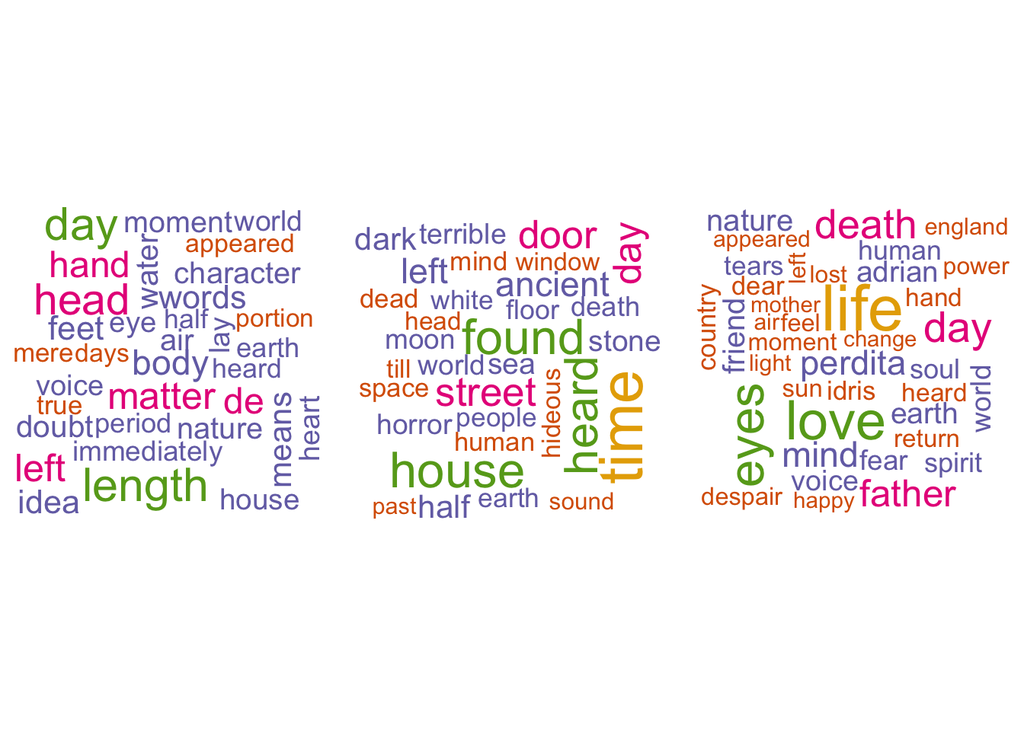

```r
#Wordcloud for each wuthor
#Function to generate dataset for each author
get_common_words_by_author <- function(x, author, remove.stopwords = FALSE){
  if(remove.stopwords){
    x <- x %>% dplyr::anti_join(stop_words)
  }

  x[x$author == author,] %>%
    dplyr::count(word, sort = TRUE)
}
words_EAP <- get_common_words_by_author(x = spooky_wrd,
                           author = "EAP",
                           remove.stopwords = TRUE)
words_HPL <- get_common_words_by_author(x = spooky_wrd,
                           author = "HPL",
                           remove.stopwords = TRUE)
words_MWS <- get_common_words_by_author(x = spooky_wrd,
                           author = "MWS",
                           remove.stopwords = TRUE)
pal <- brewer.pal(6,"Dark2")
layout(matrix(c(1,2,3),1,3,byrow = T))
par(mar = c(0,0,0,0))
#EAP
wordcloud(words_EAP$word,words_EAP$n,max.words = 50,colors =pal)
#HPL
wordcloud(words_HPL$word,words_HPL$n,max.words = 50,colors =pal)
#MWS
wordcloud(words_MWS$word,words_MWS$n,max.words = 50,colors =pal)
```

### 1.2 TF-IDF

TF stands for term frequency or how often a word appears in a text and it is what is studied above in the word cloud. IDF stands for inverse document frequncy, and it is a way to pay more attention to words that are rare within the entire set of text data that is more sophisticated than simply removing stop words. Multiplying these two values together calculates a term’s tf-idf, which is the frequency of a term adjusted for how rarely it is used. We’ll use tf-idf as a heuristic index to indicate how frequently a certain author uses a word relative to the frequency that ll the authors use the word. Therefore we will find words that are characteristic for a specific author, a good thing to have if we are interested in solving the author identification problem.

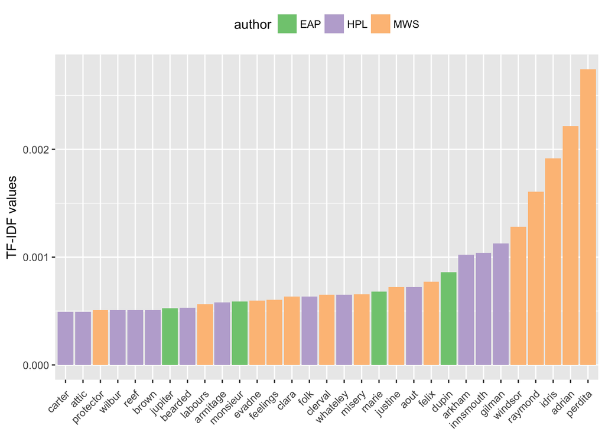

```r
frequency <- count(spooky_wrdnew, author, word)
tf_idf    <- bind_tf_idf(frequency, word, author, n)

tf_idf <- arrange(tf_idf, desc(tf_idf))
tf_idf <- mutate(tf_idf, word = factor(word, levels = rev(unique(word))))
tf_idf_30 <- top_n(tf_idf, 30, tf_idf)

ggplot(tf_idf_30) +
  geom_col(aes(word, tf_idf, fill = author)) +
  labs(x = NULL, y = "TF-IDF values") +
  theme(legend.position = "top", axis.text.x  = element_text(angle=45, hjust=1, vjust=0.9))+
  scale_fill_brewer(palette = 'Accent')
```

Note that in the above, many of the words recognized by their tf-idf scores are names. This makes sense – if we see text referencing Raymond, Idris, or Perdita, we know almost for sure that MWS is the author. But some non-names stand out. EAP often uses “monsieur” and “jupiter” while HPL uses the words “bearded” and “attic” more frequently than the others.

We can also look at the most characteristic terms per author.

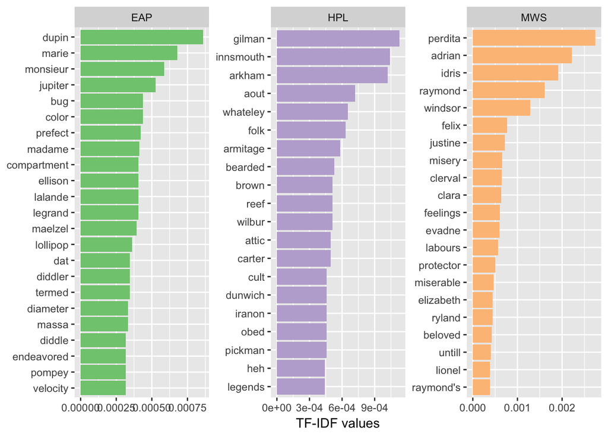

```r
tf_idf <- ungroup(top_n(group_by(tf_idf, author), 20, tf_idf))

ggplot(tf_idf) +
  geom_col(aes(word, tf_idf, fill = author)) +
  labs(x = NULL, y = "tf-idf") +
  theme(legend.position = "none") +
  facet_wrap(~ author, ncol = 3, scales = "free") +
  coord_flip() +
  labs(y = "TF-IDF values")+
  scale_fill_brewer(palette = 'Accent')
```

- Naturally, we recover our top ranking words such as “Perdita” or “Arkham”. But here we also see that Mary Shelley liked the word “until” while H P Lovecraft wrote about “legends”.
- Edgar Allan Poe’s work contains some interesting technical terms such as “diameter” or “velocity”. And “lollipop”, which is, admittedly, somewhat less scary than expected. Unless it is a lollipop made from … blood!

Too many arcane words in this section… I have a hard time searching their meanings, Still Couldn’t Understand what they want to convey without context…Maybe in next parts it will reveal more interesting facts.

## 2.Bigrams

### 2.1 TF-IDF

Let’s start with those bigrams. We can extract all of those pairs in a very similar way as the individual words using our magical *tidytext* scissors. Here are a few random examples that will change every time we run this part:

```r
t2 <- spooky %>% select(author, text) %>% unnest_tokens(bigram, text, token = "ngrams", n = 2)
sample_n(t2, 5)
```

```
##        author         bigram
## 6719      EAP shingles broad
## 91022     EAP       not have
## 223861    HPL a confidential
## 296082    HPL when subjected
## 137011    EAP          to be
```

In order to filter out the stop words we need to *separate* the bigrams first, and then later *unite* them back together after the filtering. *Separate/unite* are also the names of the corresponding *dplyr* functions:

```r
bi_sep <- t2 %>%
  separate(bigram, c("word1", "word2"), sep = " ")

bi_filt <- bi_sep %>%
  filter(!word1 %in% stop_words$word) %>%
  filter(!word2 %in% stop_words$word)

# for later
bigram_counts <- bi_filt %>%
  count(word1, word2, sort = TRUE)

t2 <- bi_filt %>%
  unite(bigram, word1, word2, sep = " ")
```

Now we can extract the TF-IDF values.

```r
t2_tf_idf <- t2 %>%
  count(author, bigram) %>%
  bind_tf_idf(bigram, author, n) %>%
  arrange(desc(tf_idf))
```

And then we plot the bigrams with the highest TF-IDF values per *author* and we see that …

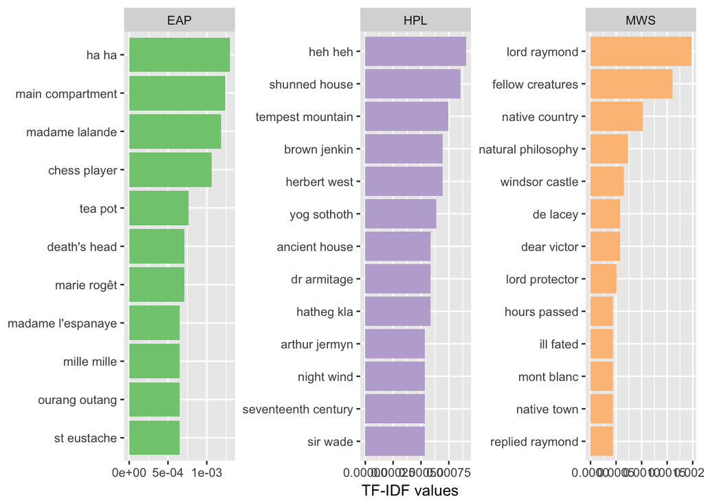

```r
t2_tf_idf %>%
  arrange(desc(tf_idf)) %>%
  mutate(bigram = factor(bigram, levels = rev(unique(bigram)))) %>%
  group_by(author) %>%
  top_n(10, tf_idf) %>%
  ungroup() %>%
  ggplot(aes(bigram, tf_idf, fill = author)) +
  geom_col() +
  labs(x = NULL, y = "TF-IDF values") +
  theme(legend.position = "none") +
  facet_wrap(~ author, ncol = 3, scales = "free") +
  coord_flip()+
  scale_fill_brewer(palette = 'Accent')
```

Um… I have the indistinct feeling that both Poe and Lovecraft are laughing at us. If there is only one thing in the world that should make you feel uneasy, it’s probably laughter from those two.

We also find:

- Besides cruel humour, for Poe it’s all about “chess players” and “tea pots”. We’ve also got a few more names and, apparently, a fair share of “Orang Utan” appearances.
- Lovecraft sets the scence with “ancient houses” and “shunned houses” during the “seventeenth century”. Also he has a couple of characteristic character names.
- So has Mary Shelly, who seems to really like “Lord Raymond”. Well, everybody loves Raymond, don’t they? We also find a few turns of phrase that are typical for her, such as “fellow creatures”, “hours passed”, or “ill fated”. *Let’s hope that the latter is not an omen for our own expedition into the heart of the darkness …*

### 2.2 First Two Words(Will be used for sentence generation)

Let’s find how these authors start their sentence with.Does anyone of them have some special writing style to surperise you at the first sight?

*I will use these first words to to generate sentence for each author in the Part 2 (5).Hope It could seem like their own style and become another “spooky novel”*

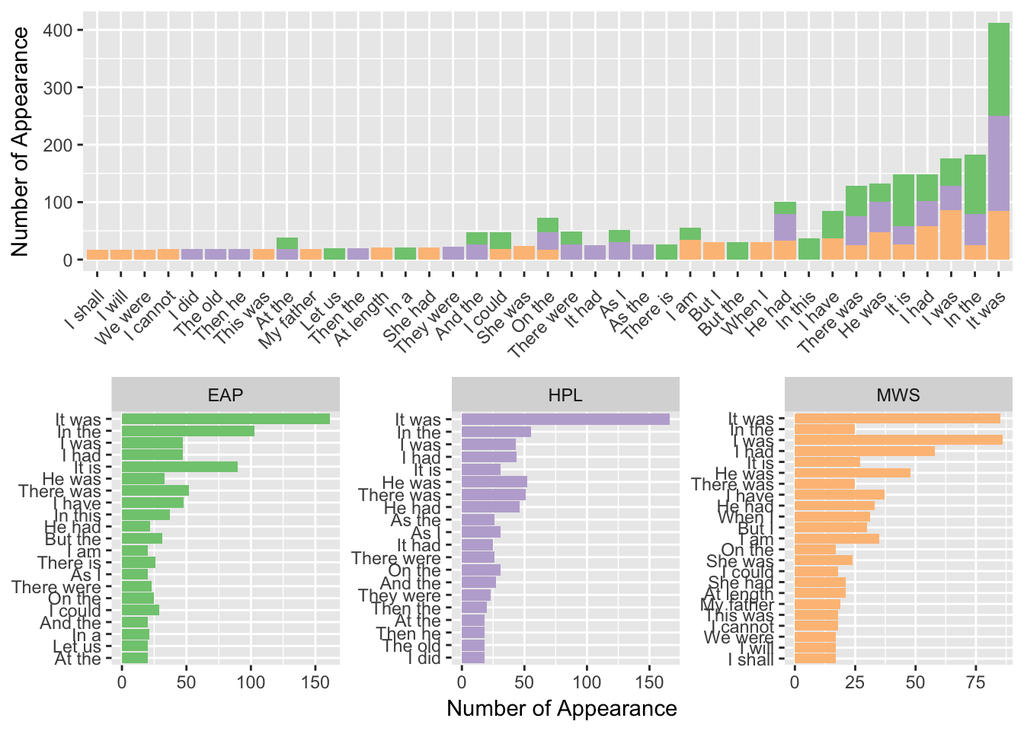

```r
spooky$first_two<-word(spooky$text, 1,2, sep=" ")
spooky_first_two<-spooky%>%
  count(author,first_two)%>%
  arrange(desc(n,author))

spooky_first_two1 <- ungroup(top_n(group_by(spooky_first_two, author), 20, n))

p1<-spooky_first_two1 %>%
  ggplot(aes(reorder(first_two,n), n, fill = author), position = position_stack(reverse = TRUE)) +
  geom_col() +
  labs(x = NULL, y = "Number of Appearance") +
  theme(legend.position = "none",axis.text.x  = element_text(angle=45, hjust=1, vjust=0.9))+
  scale_fill_brewer(palette = 'Accent')

p2<-spooky_first_two1 %>%
  ggplot(aes(reorder(first_two,n), n, fill = author), position = position_stack(reverse = TRUE)) +
  geom_col() +
  labs(x = NULL, y = "Number of Appearance") +
  theme(legend.position = "none")+
  facet_wrap(~ author, ncol = 3, scales = "free") +
  coord_flip()+
  scale_fill_brewer(palette = 'Accent')

layout <- matrix(c(1, 2), 2, 1, byrow = TRUE)
multiplot(p1, p2, layout = layout)
```

- EAP and HPL have very similar Starting Words, EAP used more “In the” and “It is” than HPL. Souds like EAP has more to explain in the sentence and stored lots of information.
- EAP seems like the most normal author when starting the sentence, EAP almost has no “own” starting words whie HPL has a perference for “As the”,“It had”,“There were”,“Then he”,“The old”,“I did”
- MWS seems has her own style to start the sentence. MWS used a small percentage common words for starting.She showed a strong love to start with “I was”,“I shall”,“I had”,“We were”,“I cannot”,“But I”… She usually start with Personal Pronouns especially “I”. Maybe MWS make more efforts to make readers has similar feeling with her or help readers get addicted to her stories?

*According to the frequency, I would select “It was” for EAP and HPL to generate “their” sentences. “I was” will be prepared for MWS*

## 3.Trigrams

### 3.1 Without Stopwords

*Three is a magical number. A terrible number. There were 3 witches to foretell Macbeth his blood-drenched destiny. The devil hound Cerberus has 3 heads. The number of the beast is 3 times the number 3+3. All these warning signs try to reach our concience as we prepare to repeat the same analysis we had done for bigrams on their cousins thrice removed: trigrams.*

*Blind for knowledge, yielding to the call of power just like the sorcerer’s apprentice, we continue our study. We crave to know more. A little spark of reason and self-preservation is trying to make itself heard against the raging thirst in our brains, but it burns ever weaker as the candle, is it still a candle?, shines brighter and brighter.*

Extracting trigrams follows the same procedure as for bigrams. Again we filter out stop words and include a few random examples:

```r
t3 <- spooky %>% select(author, text) %>% unnest_tokens(trigram, text, token = "ngrams", n = 3)

tri_sep <- t3 %>%
  separate(trigram, c("word1", "word2", "word3"), sep = " ")

tri_filt <- tri_sep %>%
  filter(!word1 %in% stop_words$word) %>%
  filter(!word2 %in% stop_words$word) %>%
  filter(!word3 %in% stop_words$word)

# for later
trigram_counts <- tri_filt %>%
  count(word1, word2, word3, sort = TRUE)

t3 <- tri_filt %>%
  unite(trigram, word1, word2, word3, sep = " ")

sample_n(t3, 5)
```

```
##       author                             trigram
## 13055    MWS         wishes shakspeare's sonnets
## 4249     EAP            departed astounding news
## 3845     EAP strangeness vastness definitiveness
## 11720    MWS               amidst eternal spring
## 6334     HPL              paper wholly unrelated
```

And here is the corresponding TF-IDF plot for the most characteristic terms:

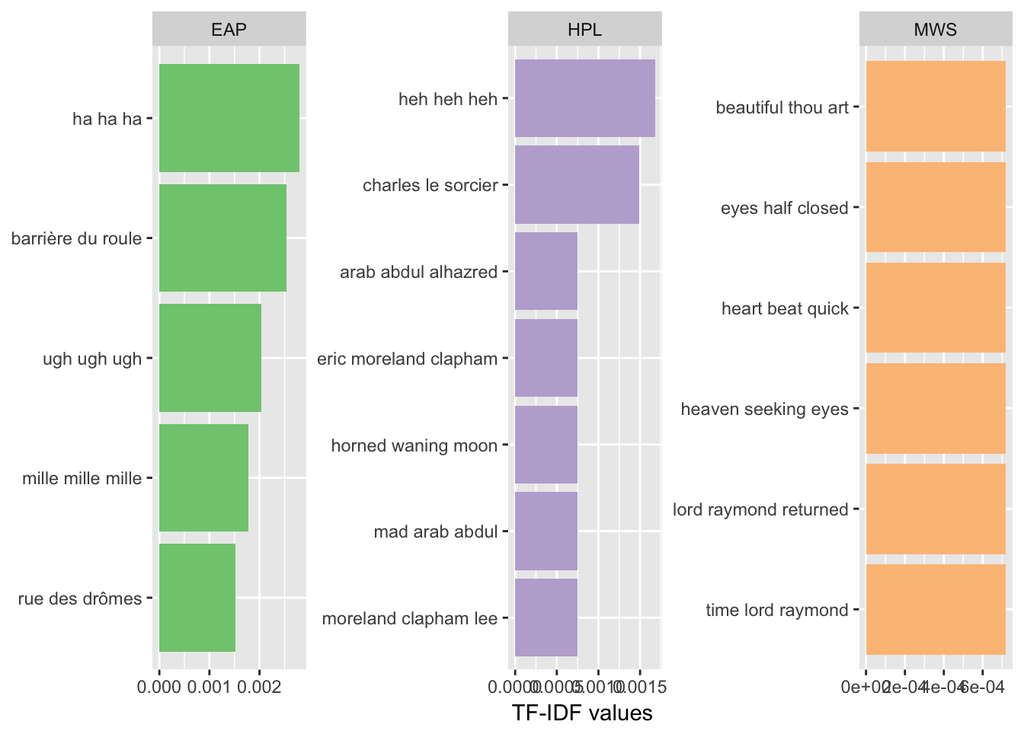

```r
t3_tf_idf <- t3 %>%
  count(author, trigram) %>%
  bind_tf_idf(trigram, author, n) %>%
  arrange(desc(tf_idf))

t3_tf_idf %>%
  arrange(desc(tf_idf)) %>%
  mutate(trigram = factor(trigram, levels = rev(unique(trigram)))) %>%
  group_by(author) %>%
  top_n(5, tf_idf) %>%
  ungroup() %>%
  ggplot(aes(trigram, tf_idf, fill = author)) +
  geom_col() +
  labs(x = NULL, y = "TF-IDF values") +
  theme(legend.position = "none") +
  facet_wrap(~ author, ncol = 3, scales = "free") +
  coord_flip()+
  scale_fill_brewer(palette = 'Accent')
```

We find:

- More scary laughter and characteristic names from Poe and Lovecraft. Feel free to admit that you also read “Eric Moreland Clap**ton**” at first glance in HPL’s list. I like the imagery of a “horned waning moon”.
- Curiously, Mary Shelley does not seem to have particularly typical phrases she repeats more often than others. The ones she does use suggest a penchant for body language, especially the eyes.
- Most importantly, though, we find out that Raymond was from [Galifrey](https://en.wikipedia.org/wiki/Time_Lord). That might explain why he’s so popular and why he manages to exert such a strong influence on Shelley’s writing.

### 3.2 With Stopwords

This time let’s put stopwords into consideration and see whether it could add more interests in their expression.

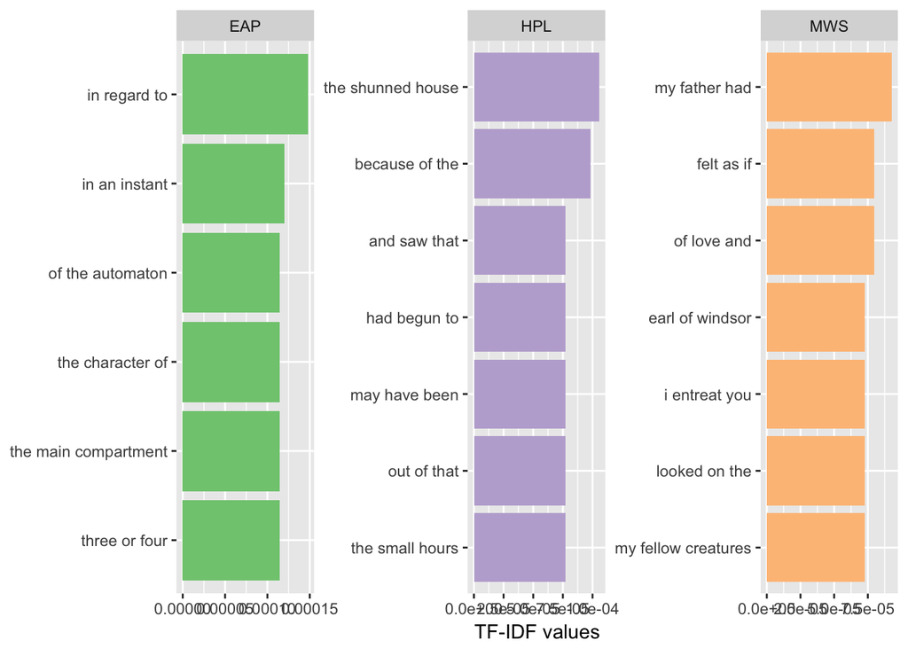

```r
trigram_counts2 <- tri_sep %>%
  count(word1, word2, word3, sort = TRUE)

t31 <- tri_sep %>%
  unite(trigram, word1, word2, word3, sep = " ")

t3_tf_idf1 <- t31 %>%
  count(author, trigram) %>%
  bind_tf_idf(trigram, author, n) %>%
  arrange(desc(tf_idf))

t3_tf_idf1 %>%
  arrange(desc(tf_idf)) %>%
  mutate(trigram = factor(trigram, levels = rev(unique(trigram)))) %>%
  group_by(author) %>%
  top_n(5, tf_idf) %>%
  ungroup() %>%
  ggplot(aes(trigram, tf_idf, fill = author)) +
  geom_col() +
  labs(x = NULL, y = "TF-IDF values") +
  theme(legend.position = "none") +
  facet_wrap(~ author, ncol = 3, scales = "free") +
  coord_flip()+
  scale_fill_brewer(palette = 'Accent')
```

We find:

- EAP and HPL are still similar in their writing style. Their trigrams are almost all conjunctions which don’t have much information
- EAP used “three or four” frequently, Checking back to the original sentences, what follows the quantitive amout is usually time(“weeks”,“hours”,“days”…). Seems like EAP tends to describe things vaguely and create some unclear concepts for reader to guess?
- HPL are fond of house! Could he afford his own house back to his time? The high house price made him scary??
- MWS gives more information on this part. My father?? My fellow creatures?? I entreat you?? She really loves using person prons in the sentence. Her trigram doesn’t seems could be compiled to a spooky novel… It made me feel warm…

## 4.Feature Engineering

We’ll do some simple numerical summaries of the data to provide some nice visualizations.Here we add some Features to the `spooky` datasets. The fatures are

- Number of commas, semicolons, colons, questions
- Number of blanks,others
- Number of words beginning with Capitals, words with Capitals
- Number of words,stopwords,negation words
- Sentence length(characters); Word length(characters)

We may find some traces how these author *cooking* their horrible books!

Some these features have been borrowed from Kaggler *jayjay* ’s kernel found [here](https://www.kaggle.com/jayjay75/text2vec-glmnet). Great work jayjay!

```r
createFE = function(ds)
{
  ds = ds %>%
  mutate(Ncommas = str_count(ds$text, ",")) %>%
  mutate(Nsemicolumns = str_count(ds$text, ";")) %>%
  mutate(Ncolons = str_count(ds$text, ":")) %>%
  mutate(Nblank = str_count(ds$text, " ")) %>%
  mutate(Nother = str_count(ds$text, "[\\.\\.]")) %>%
  mutate(Ncapitalfirst = str_count(ds$text, " [A-Z][a-z]")) %>%
  mutate(Ncapital = str_count(ds$text, "[A-Z]")) %>%
  mutate(Nquestion = str_count(ds$text,"\\?"))

  return(ds)
}
spooky_feature = createFE(spooky)
```

### 4.1 Sentence Ingredients

Here comes their “Sentence Ingredients”! This part tell us How Much Special Ingredients they Add in Their Stories.

First is the number of Capital they used

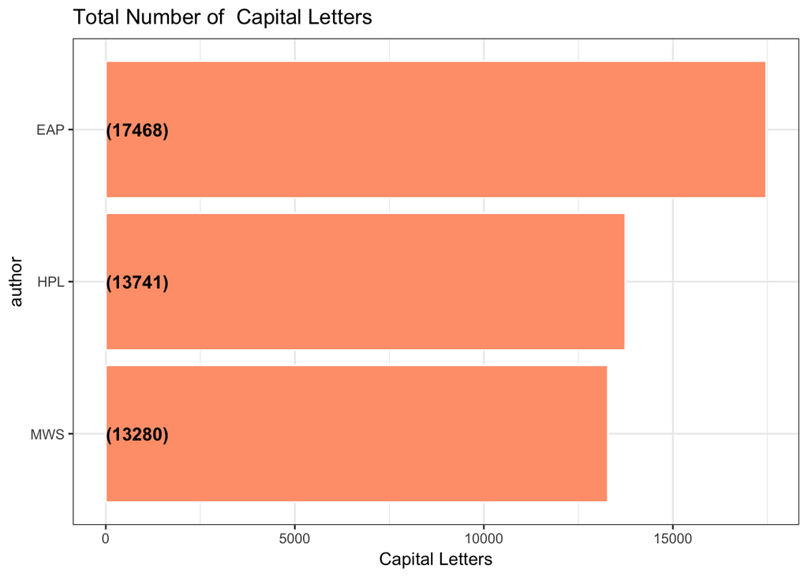

```r
spooky_feature %>%
  group_by(author) %>%
  summarise(SumCapital = sum(Ncapital,na.rm = TRUE)) %>%
  ungroup() %>%
  mutate(author = reorder(author,SumCapital)) %>%

  ggplot(aes(x = author,y = SumCapital)) +
  geom_bar(stat='identity',colour="white", fill = fillColor) +
  geom_text(aes(x = author, y = 1, label = paste0("(",SumCapital,")",sep="")),
            hjust=0, vjust=.5, size = 4, colour = 'black',
            fontface = 'bold') +
  labs(x = 'author',
       y = 'Capital Letters',
       title = 'Total Number of  Capital Letters') +
  coord_flip() +
  theme_bw()
```

- Seems like EAP used more Capital Letters,But there are also more sentence included in the dataset writen by EAP.(EAP,HPL,MWS :7900,5635,6044) After Calculating the Captical Letters Per Sentence, HPL won! EAP and MWS have an average of 2.2 per sentence while HPL has 2.4.

Next comes the number of words in a sentence.

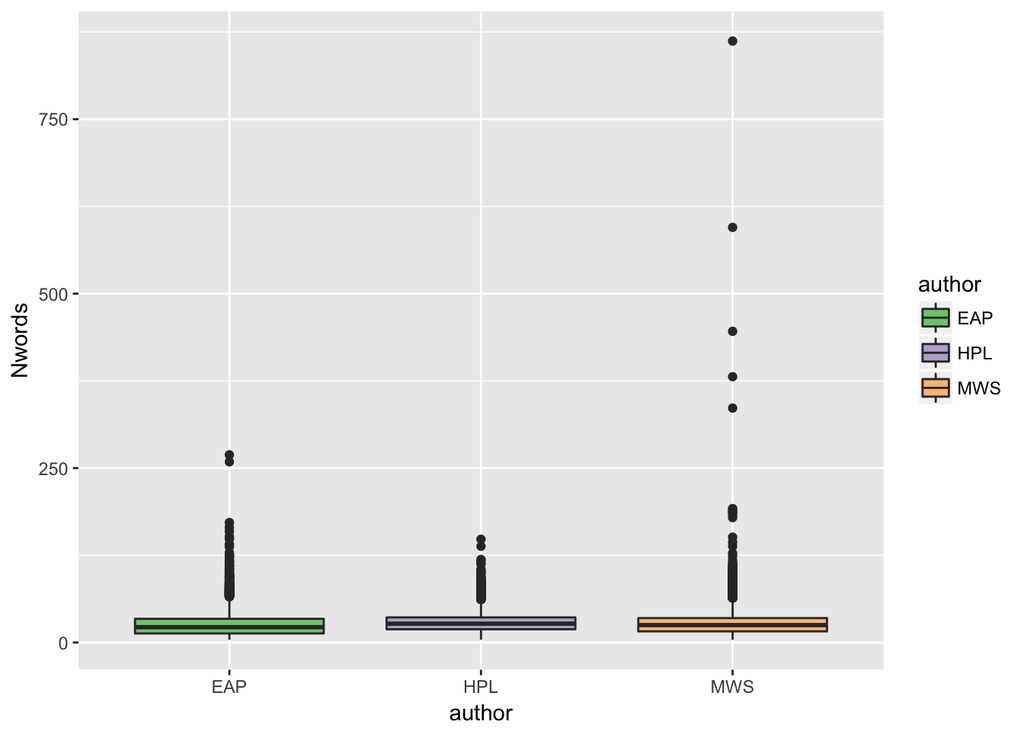

```r
spooky_feature$Nwords <- sapply(gregexpr("\\W+", spooky_feature$text), length) + 1
ggplot(spooky_feature) +
  geom_boxplot(aes(x=author, y=Nwords,fill=author))+
  scale_fill_brewer(palette = 'Accent')
```

- HPL has a relatively long sentence than others while MWS occassionaly write some extrmely long sentence.
- HPL is very stable and have a steady performance when add words into his stories while MWS seems very flexible and sometimes may has A Burst of Inspiration??

Then comes number of stopwords in a sentence

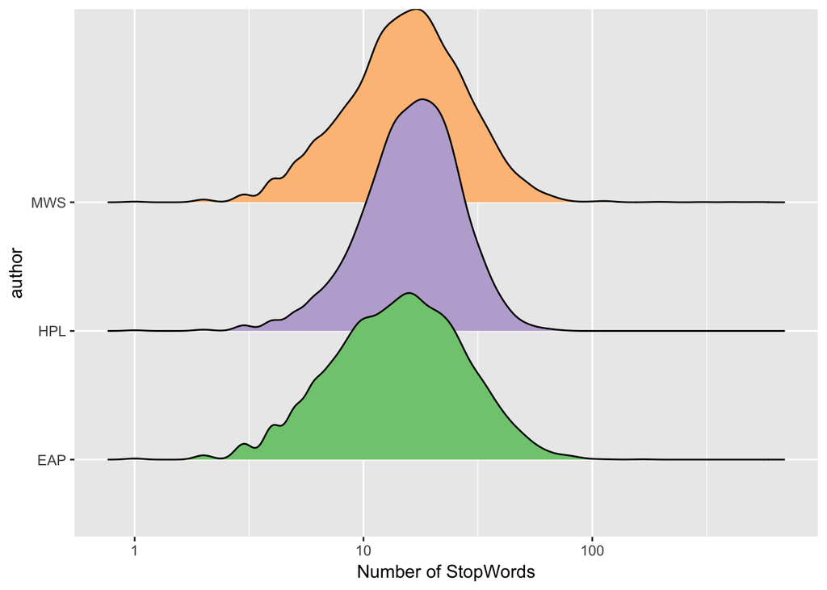

```r
nostopword<-as.data.frame(table(spooky_wrdnew$id))
names(nostopword)<-c("id","num_of_nostop_wrd")
spooky_feature<-merge(spooky_feature,nostopword,by="id",all=T)
spooky_feature$num_of_nostop_wrd[is.na(spooky_feature$num_of_nostop_wrd)]<-0
spooky_feature$Nstop<-spooky_feature$Nwords - spooky_feature$num_of_nostop_wrd

ggplot(spooky_feature) +
      geom_density_ridges(aes(Nstop, author, fill = author)) +
      scale_x_log10() +
      theme(legend.position = "none") +
      labs(x = "Number of StopWords")+
  scale_fill_brewer(palette = 'Accent')
```

At last,it is the number of negation words in a sentence

**Negation Words**:  
Different from negative words in sentiment analysis,including:  
*Negative words*: no,not,none,no one,nobody,nothing,neither,nowhere,never  
*Negative Adverbs*: hardly,scarcely,barely  
*Negative verbs*: doesn’t,isn’t,wasn’t,shouldn’t,wouldn’t,couldn’t,won’t,can’t,don’t  
*Others*: little,few,nor,neither…nor,without,unless,but for,but that,in the absence of,regardless of,instead of,exclusive of,short of,rather than,anything but,any more than,would no more…than

I didn’t find a existing word list for this….So I just generated some by myself. Correct me if I am wrong.

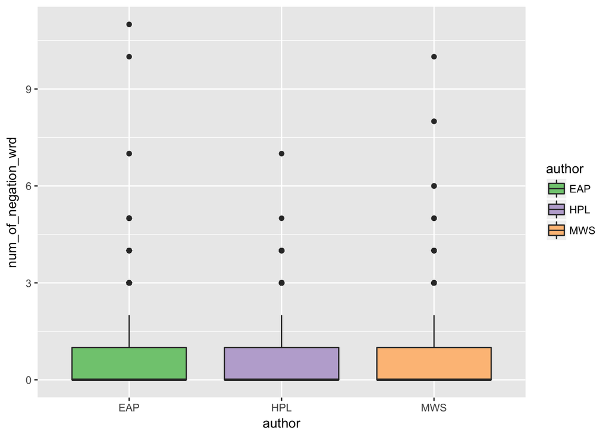

```r
negation<-c("no","not","none","nobody","nothing","neither","nowhere","never","hardly","scarcely","barely","doesn't","isn't","wasn't","shouldn't","wouldn't","didn't","won't","can't","little","few","nor","neither","without","unless","wa'n't","dun't","dxn't","aren't","hasn't","couldn't","hadn't","don't","mustn't","ain't","haven't","wudn't","weren't")
spooky_wrd$negation <- spooky_wrd$word %in% negation
negationwrd<-as.data.frame(table(spooky_wrd$id[spooky_wrd$negation==T] ))
names(negationwrd)<-c("id","num_of_negation_wrd")
spooky_feature<-merge(spooky_feature,negationwrd,by="id",all=T)
spooky_feature$num_of_negation_wrd[is.na(spooky_feature$num_of_negation_wrd)]<-0

ggplot(spooky_feature) +
  geom_boxplot(aes(x=author, y=num_of_negation_wrd,fill=author))+
  scale_fill_brewer(palette = 'Accent')
```

- They almost have the same performance and only EAP may use a little more negation words.

Overall, we could find HPL has a very good writing habit, moderate length, moderate words number, Good example for us. He may never added too much butter to his bread…

### 4.2 Sentence Seasoning(Punctuations)

After checking their ingradients, what did they put for the “Flavour”? The bar plot shows the authors with the Total Number of Commas,SemiColons,Colons,Questions used by them. Still, be careful because EAP appeared more ofen than others.

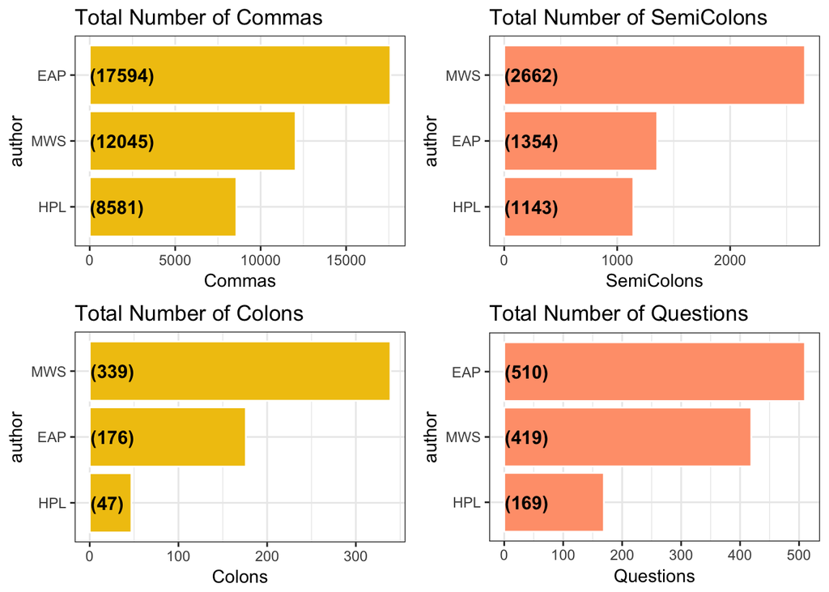

```r
p1<-spooky_feature %>%
  group_by(author) %>%
  summarise(SumCommas = sum(Ncommas,na.rm = TRUE)) %>%
  ungroup() %>%
  mutate(author = reorder(author,SumCommas)) %>%

  ggplot(aes(x = author,y = SumCommas)) +
  geom_bar(stat='identity',colour="white", fill = fillColor2) +
  geom_text(aes(x = author, y = 1, label = paste0("(",SumCommas,")",sep="")),
            hjust=0, vjust=.5, size = 4, colour = 'black',
            fontface = 'bold') +
  labs(x = 'author',
       y = 'Commas',
       title = 'Total Number of Commas') +
  coord_flip() +
  theme_bw()

p2<-spooky_feature %>%
  group_by(author) %>%
  summarise(SumSemiColons = sum(Nsemicolumns,na.rm = TRUE)) %>%
  ungroup() %>%
  mutate(author = reorder(author,SumSemiColons)) %>%

  ggplot(aes(x = author,y = SumSemiColons)) +
  geom_bar(stat='identity',colour="white", fill = fillColor) +
  geom_text(aes(x = author, y = 1, label = paste0("(",SumSemiColons,")",sep="")),
            hjust=0, vjust=.5, size = 4, colour = 'black',
            fontface = 'bold') +
  labs(x = 'author',
       y = 'SemiColons',
       title = 'Total Number of SemiColons') +
  coord_flip() +
  theme_bw()

p3<-spooky_feature %>%
  group_by(author) %>%
  summarise(SumColons = sum(Ncolons,na.rm = TRUE)) %>%
  ungroup() %>%
  mutate(author = reorder(author,SumColons)) %>%

  ggplot(aes(x = author,y = SumColons)) +
  geom_bar(stat='identity',colour="white", fill = fillColor2) +
  geom_text(aes(x = author, y = 1, label = paste0("(",SumColons,")",sep="")),
            hjust=0, vjust=.5, size = 4, colour = 'black',
            fontface = 'bold') +
  labs(x = 'author',
       y = 'Colons',
       title = 'Total Number of Colons') +
  coord_flip() +
  theme_bw()

p4<-spooky_feature %>%
  group_by(author) %>%
  summarise(SumQuestions = sum(Nquestion,na.rm = TRUE)) %>%
  ungroup() %>%
  mutate(author = reorder(author,SumQuestions)) %>%

  ggplot(aes(x = author,y = SumQuestions)) +
  geom_bar(stat='identity',colour="white", fill = fillColor) +
  geom_text(aes(x = author, y = 1, label = paste0("(",SumQuestions,")",sep="")),
            hjust=0, vjust=.5, size = 4, colour = 'black',
            fontface = 'bold') +
  labs(x = 'author',
       y = 'Questions',
       title = 'Total Number of Questions') +
  coord_flip() +
  theme_bw()

layout <- matrix(c(1, 2, 3, 4), 2, 2, byrow = TRUE)
multiplot(p1, p2, p3,p4, layout = layout)
```

- HPL cherishes his Commas, Colons and Questions and only used little seasoning…
- MWS is almost wasting Semicolons and Colons compared to others…

## 5.Sentence Generation

In the current example I’m using all the phrases I extracted from the trigrams. And then well use words that follow each other choosing “randomly” but weighted by occurrence.

My endproduct takes two words and tries to find a third word. Then it takes the final two words and tries to find another word untill the sentance has a length that I specify at the start.

What I actually created is a trigram dataframe, and a function that searches that frame. The function takes two words and returns all the rows where the first word matches the first column and the second word matches the second column.

Furthermore I made a sentence creator, a function where you supply the first two words and the length of the sentence. That function keeps using the last words in the sentence until the correct length is achieved. With the fallback method of using bigrams when the trigrams don’t work anymore it could still fail, but not so often.

According to what we got from Part 2 (2.2), I generated sentences using the most frequent starting words used by each author. “It was”,“It was”,“I was” for EAP HPL and MWS respectively.

*Please input sentence length above 3*  
*If there are imporper word inputed(such as “i” & “no” which couldn’t be linked together used as approporite starting words for a sentence), it will print “Change the starting words or sentence length/Rerun the code”*

```r
#trigram of authors
trigrams_EAP <- spooky %>%
        filter(author == "EAP") %>%
        unnest_tokens(trigram, text, token = "ngrams",to_lower = TRUE, n= 3) %>%
        separate(trigram, c("word1", "word2", "word3"), sep = " ") %>%
        count(word1, word2,word3, sort = TRUE)
trigrams_HPL <- spooky %>%
        filter(author == "HPL") %>%
        unnest_tokens(trigram, text, token = "ngrams",to_lower = TRUE, n= 3) %>%
        separate(trigram, c("word1", "word2", "word3"), sep = " ") %>%
        count(word1, word2,word3, sort = TRUE)
trigrams_MWS <- spooky %>%
        filter(author == "MWS") %>%
        unnest_tokens(trigram, text, token = "ngrams",to_lower = TRUE, n= 3) %>%
        separate(trigram, c("word1", "word2", "word3"), sep = " ") %>%
        count(word1, word2,word3, sort = TRUE)

##sentence generator
return_third_word <- function( woord1, woord2,authordata){
        temp<-authordata%>%
          filter_(~word1 == woord1, ~word2 == woord2)
        if (dim(temp)[1]==0){
          print("Change the starting words or sentence length you inputed/Rerun the code")
        }
        else{
        woord <- temp %>%
                sample_n(size=1, weight = n,replace = T) %>%
                .[["word3"]]
        #seems useless?
        if(length(woord) == 0){
                bleh <- filter_(authordata, ~word1 == woord2) %>%
                        sample_n(1, weight = n)
                warning("no word found, adding ", bleh, "to", woord1 , woord2)
                woord <- bleh
        }
        woord
        }
}
#for test: return_third_word("i","s",trigrams_EAP)
generate_sentence <- function(word1, word2,authordata, sentencelength =5, debug =FALSE){
        #input validation
        #if(sentencelength <3)stop("I need more to work with")
        sentencelength <- sentencelength -2
        # starting
        sentence <- c(word1, word2)
        woord1 <- word1
        woord2 <- word2
        for(i in seq_len(sentencelength)){
                #if(debug == TRUE)print(i)
                word <- return_third_word( woord1, woord2, authordata )
               # if(return_third_word( woord1, woord2, authordata )=="Change the word you inputed")
                #  print("Rerun please")else
                sentence <- c(sentence, word)
                woord1 <- woord2
                woord2 <- word
        }
        output <-paste(sentence, collapse = " ")
        output
}
generate_sentence("it", "was",trigrams_EAP, 6)
```

```
## [1] "it was an elm of fine"
```

```r
generate_sentence("it", "was",trigrams_HPL, 6)
```

```
## [1] "it was now close to the"
```

```r
generate_sentence("i", "was",trigrams_MWS, 6)
```

```
## [1] "i was obliged to form friendships"
```

Examples with the most frequent starting words for each author:

*EAP

[1] “it was only with difficulty shake off incumbent eternally upon my word mark that”

[1] “it was her beauty in my opinion by certain superstitious impressions in view of”

[1] “it was sitting alone in his eyes became unwittingly rivetted”

[1] “it was clear that the doom prepared for me”

[1] “it was the last eventful scene of the magnificent”

*HPL

[1] “it was his mountain freedom that he thought he heard about the matter for speculation”

[1] “it was at a glance doubly absurd since the garret chamber were wholly beyond conjecture”

[1] “it was the ultimate things i have dwelt ever in realms apart from their”

[1] “it was probably merely a fresh bending and matting visible”

[1] “it was not his own hands reached out to uncurl”

*MWS

[1] “i was gradually recovering i was shut out from crackling branches of the seas rather”

[1] “i was perplexed and unable to arrange my ideas seemed to hold out longer”

[1] “i was acting for the cottage they consisted of paradise”

[1] “i was happy and with a reinforcement they had”

[1] “i was gradually recovering i was so much desired”

We could change the first two words, author number of words in the sentence. But usually the shorter the sentence, the more reasonable the meaning.

I didn’t get too much insight from the “Machine Sentence” hhh. From my perspective, the only difference is there are more strange words I am unfamilar with in EAP and HPL’s sentences…Seems like MWS is more user friendly?

We could explore more about how those authors describe the world or life or anything else in their sentence by changing the first two words. This may reflect their attitudes and values.

How they describe the world

```r
generate_sentence("world", "was",trigrams_EAP, 6)
```

```
## [1] "Change the starting words or sentence length you inputed/Rerun the code"
## [1] "Change the starting words or sentence length you inputed/Rerun the code"
```

```
## [1] "world was still running Change the starting words or sentence length you inputed/Rerun the code Change the starting words or sentence length you inputed/Rerun the code"
```

```r
generate_sentence("world", "was",trigrams_HPL, 6)
```

```
## [1] "world was made up and count"
```

```r
generate_sentence("world", "was",trigrams_MWS, 6)
```

```
## [1] "world was to quit geneva forever"
```

*EAP [1] “the world grew dark before mine”

[1] “the world grew dark before mine eyes in an attitude”

*HPL [1] “the world or no longer controls”

[1] “the world battling against blackness against the rotting remains of”

*MWS [1] “the world had grown stale to”

[1] “the world is come before dawn i led a young”

How they describe life.

```r
generate_sentence("life", "was",trigrams_EAP, 6)
```

```
## [1] "life was the fair forms that"
```

```r
generate_sentence("life", "was",trigrams_HPL, 6)
```

```
## [1] "life was exceedingly secluded and people"
```

```r
generate_sentence("life", "was",trigrams_MWS, 6)
```

```
## [1] "life was to be scattered by"
```

EAP [1] “life was in search of the calling a”

[1] “life was in truth the masquerade license of”

HPL [1] “life was known to barzai the wise shrieking”

[1] “life was confined to the southeast and now”

MWS [1] “life was now united to his past life”

[1] “life was now awake she was miserable and”

- All the generated sentences are not so positive, fulling with “dark” and “miserable”.

# Part 3 Data Prediction

## 1.Logistics Regression

### 1.1 Multinomial Logistics Regression…

I tried to use “Ncommas”,“Nsemicolumns”,“Ncolons”,“Ncapital”,“Nquestion”,“Nwords”,“num_of_negation_wrd”,“sen_length” to predict the author…but stuck in this part… I listed some material I used for the code but I still didn’t understand the principle of Multinominal Logistics Regression enough…

Please correct me

*[How to: Multinomial regression models in R](https://www.r-bloggers.com/how-to-multinomial-regression-models-in-r/)*

*[R examples](https://stats.idre.ucla.edu/r/dae/multinomial-logistic-regression/)*

*[How to: Multinomial regression models in R](https://www.r-bloggers.com/how-to-multinomial-regression-models-in-r/)*

First I added sentence length(characters) and word length(characters) to dataset.

```r
spooky$sen_length <- str_length(spooky$text)
spooky_wrdnew$word_length <- str_length(spooky_wrdnew$word)
```

Used correlation plots to delete variables.

*You may need to download the package **corrplot** to run the code.*

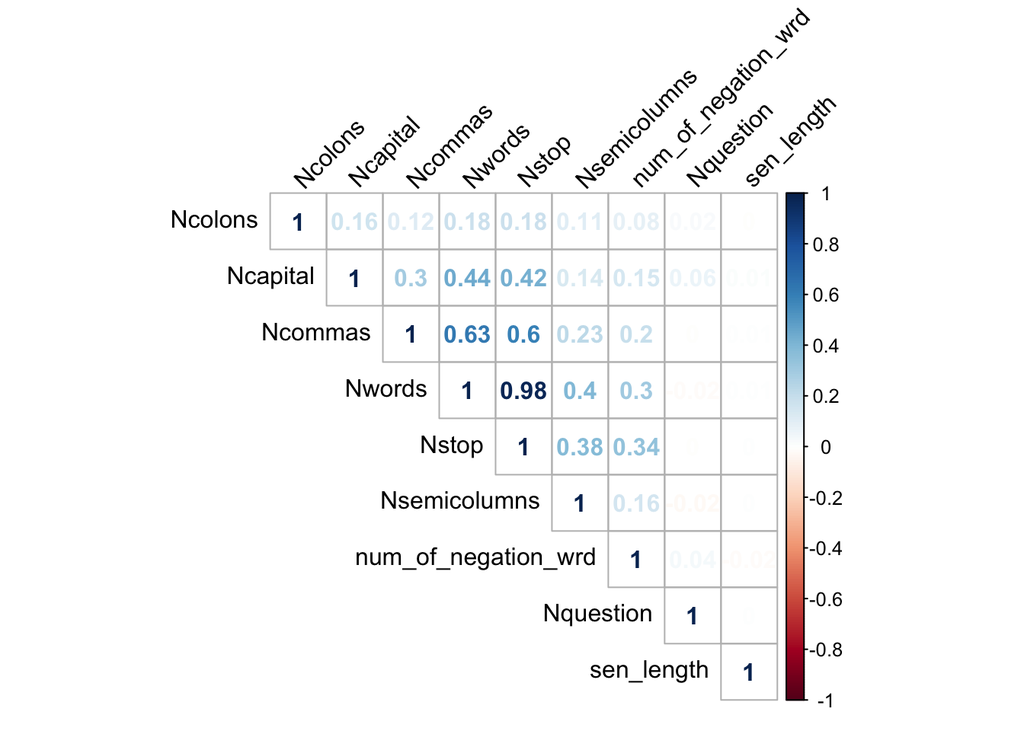

```r
spooky_feature$sen_length<-spooky$sen_length
regressiondata<-spooky_feature[,c(-1,-2,-4,-8,-9,-10,-14)]
#install.packages("corrplot")
library(corrplot)
m<-cor(regressiondata[,2:10])
corrplot(m, type = "upper", order = "hclust", tl.col = "black", tl.srt = 45,method = "number")
```

I found number of words has a high correlation with number of stopwords,so I deleted the number of stop words from the variables. Correlation again.

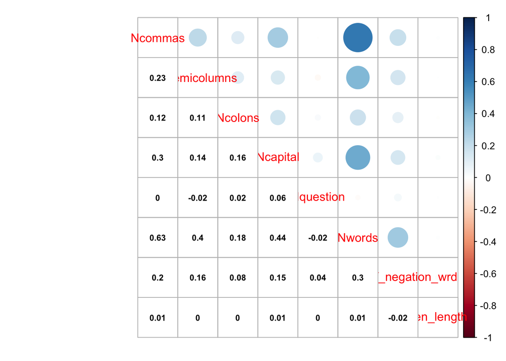

```r
regressiondata<-regressiondata[,-8]
m1<-cor(regressiondata[,2:9])
corrplot.mixed(m1, lower.col = "black", number.cex = .7)
```

Separate dataset into train and test.

```r
set.seed(4243)
sample<-sample.int(n=nrow(regressiondata),size=floor(0.75*nrow(regressiondata)),replace=F)
train<-regressiondata[sample, ]
test<-regressiondata[-sample, ]
```

Here comes my nightmare…

*You may need to download the package **nnet** to run the code.*

```r
library(nnet)
mult<-multinom(author~.,data=train)
summary(mult)
```

```
## Call:
## multinom(formula = author ~ ., data = train)
##
## Coefficients:
##     (Intercept)    Ncommas Nsemicolumns   Ncolons    Ncapital  Nquestion
## HPL  -0.8207949 -0.4862400  -0.06941065 -1.310410  0.04778457 -0.6865236
## MWS  -0.3103486 -0.1403601   0.89018293  0.823182 -0.03857027  0.1706454
##          Nwords num_of_negation_wrd   sen_length
## HPL 0.048469110          -0.1007914 1.950072e-04
## MWS 0.007439843          -0.2169053 8.165399e-05
##
## Std. Errors:
##     (Intercept)    Ncommas Nsemicolumns   Ncolons   Ncapital  Nquestion
## HPL  0.05385794 0.01707620   0.05119468 0.1948332 0.01115532 0.10309479
## MWS  0.05190771 0.01445629   0.04381850 0.1132898 0.01206451 0.07436598
##          Nwords num_of_negation_wrd   sen_length
## HPL 0.002117827          0.03255599 0.0002083105
## MWS 0.002087648          0.03229003 0.0002033088
##
## Residual Deviance: 29900.54
## AIC: 29936.54
```

Used stepwise to get a better model.

```r
stepmult<-step(mult,trace=0)
```

```
## trying - Ncommas
## trying - Nsemicolumns
## trying - Ncolons
## trying - Ncapital
## trying - Nquestion
## trying - Nwords
## trying - num_of_negation_wrd
## trying - sen_length
## trying - Ncommas
## trying - Nsemicolumns
## trying - Ncolons
## trying - Ncapital
## trying - Nquestion
## trying - Nwords
## trying - num_of_negation_wrd
```

```r
summary(stepmult)
```

```
## Call:
## multinom(formula = author ~ Ncommas + Nsemicolumns + Ncolons +
##     Ncapital + Nquestion + Nwords + num_of_negation_wrd, data = train)
##
## Coefficients:
##     (Intercept)    Ncommas Nsemicolumns   Ncolons    Ncapital  Nquestion
## HPL  -0.7921388 -0.4861095  -0.06888915 -1.311544  0.04790534 -0.6851465
## MWS  -0.2983307 -0.1403305   0.89031166  0.822829 -0.03851129  0.1709427
##          Nwords num_of_negation_wrd
## HPL 0.048465823          -0.1015623
## MWS 0.007437416          -0.2171735
##
## Std. Errors:
##     (Intercept)    Ncommas Nsemicolumns   Ncolons   Ncapital  Nquestion
## HPL  0.04424272 0.01707352   0.05118760 0.1948402 0.01115685 0.10306357
## MWS  0.04243888 0.01445593   0.04381364 0.1132716 0.01206482 0.07435822
##          Nwords num_of_negation_wrd
## HPL 0.002117582          0.03254416
## MWS 0.002087562          0.03228028
##
## Residual Deviance: 29901.41
## AIC: 29933.41
```

Predict the result of test set

```r
# put into test dataset
result<-predict(stepmult,test)
head(result)
```

```
## [1] EAP MWS EAP HPL EAP MWS
## Levels: EAP HPL MWS
```

```r
resultprob<-predict(stepmult,test,"probs")
head(resultprob)
```

```
##          EAP       HPL       MWS
## 3  0.4025806 0.3410807 0.2563388
## 5  0.2681899 0.2706456 0.4611645
## 6  0.4635858 0.2419635 0.2944507
## 8  0.1960105 0.5187672 0.2852223
## 9  0.3853511 0.3273241 0.2873248
## 20 0.2662128 0.2817404 0.4520467
```

Show the final comparision of predicted & true author

```r
# prediction for test
n<-table(test$author,result)
n
```

```
##      result
##        EAP  HPL  MWS
##   EAP 1449  278  212
##   HPL  767  482  183
##   MWS  854  224  446
```

```r
Percantage<-c(n[1,1]/sum(n[1,]),n[2,2]/sum(n[2,]),n[3,3]/sum(n[3,]))
Category<-levels(test$author)
rbind(Category,Percantage)
```

```
##            [,1]                [,2]               [,3]
## Category   "EAP"               "HPL"              "MWS"
## Percantage "0.747292418772563" "0.33659217877095" "0.292650918635171"
```

```r
accuracy<-sum(diag(n))/nrow(test)
accuracy
```

```
## [1] 0.4855975
```

### 1.2 Binary Logistics Regression

Logistic regression could be used on our data to make binary choices like is it MSW or not. While it seems like one should be able to use three logistic regression models (MSW or not, EAP or not, HPL or not) to classify the text, it won’t necessarily be the case that the results of the three models agree.

I will show one example (EAP or Not) here and give the result of other two.

Prepare the dataset

```r
EAPorNot<-regressiondata
EAPorNot$author<-as.character(EAPorNot$author)
EAPorNot$author[which(EAPorNot$author!="EAP")]<-"Others"
EAPorNot$author<-as.factor(EAPorNot$author)

set.seed(4243)
sample1<-sample.int(n=nrow(EAPorNot),size=floor(0.75*nrow(EAPorNot)),replace=F)
train1<-EAPorNot[sample1, ]
test1<-EAPorNot[-sample1, ]
```

Conduct regression

```r
glm<-glm(author ~.,family="binomial",data=train1)
summary(glm)
```

```
##
## Call:
## glm(formula = author ~ ., family = "binomial", data = train1)
##
## Deviance Residuals:
##     Min       1Q   Median       3Q      Max
## -3.7154  -1.2463   0.7887   1.0193   2.2923
##
## Coefficients:
##                       Estimate Std. Error z value Pr(>|z|)
## (Intercept)          0.1340426  0.0440862   3.040  0.00236 **
## Ncommas             -0.2923348  0.0126411 -23.126  < 2e-16 ***
## Nsemicolumns         0.5101122  0.0394025  12.946  < 2e-16 ***
## Ncolons              0.2064721  0.1089542   1.895  0.05809 .
## Ncapital             0.0066564  0.0095035   0.700  0.48366
## Nquestion           -0.1364122  0.0686392  -1.987  0.04688 *
## Nwords               0.0270190  0.0017473  15.463  < 2e-16 ***
## num_of_negation_wrd -0.1614936  0.0269465  -5.993 2.06e-09 ***
## sen_length           0.0001296  0.0001734   0.747  0.45489
## ---
## Signif. codes:  0 '***' 0.001 '**' 0.01 '*' 0.05 '.' 0.1 ' ' 1
##
## (Dispersion parameter for binomial family taken to be 1)
##
##     Null deviance: 19834  on 14683  degrees of freedom
## Residual deviance: 18906  on 14675  degrees of freedom
## AIC: 18924
##
## Number of Fisher Scoring iterations: 4
```

```r
#stepwise
stepglm<-step(glm,direction = "both",trace=0)
summary(stepglm)
```

```
##
## Call:
## glm(formula = author ~ Ncommas + Nsemicolumns + Ncolons + Nquestion +
##     Nwords + num_of_negation_wrd, family = "binomial", data = train1)
##
## Deviance Residuals:
##     Min       1Q   Median       3Q      Max
## -3.7336  -1.2482   0.7886   1.0185   2.3045
##
## Coefficients:
##                      Estimate Std. Error z value Pr(>|z|)
## (Intercept)          0.158930   0.035011   4.539 5.64e-06 ***
## Ncommas             -0.291922   0.012631 -23.112  < 2e-16 ***
## Nsemicolumns         0.509494   0.039370  12.941  < 2e-16 ***
## Ncolons              0.213036   0.108510   1.963   0.0496 *
## Nquestion           -0.131956   0.068416  -1.929   0.0538 .
## Nwords               0.027318   0.001696  16.107  < 2e-16 ***
## num_of_negation_wrd -0.161581   0.026932  -6.000 1.98e-09 ***
## ---
## Signif. codes:  0 '***' 0.001 '**' 0.01 '*' 0.05 '.' 0.1 ' ' 1
##
## (Dispersion parameter for binomial family taken to be 1)
##
##     Null deviance: 19834  on 14683  degrees of freedom
## Residual deviance: 18907  on 14677  degrees of freedom
## AIC: 18921
##
## Number of Fisher Scoring iterations: 4
```

```r
#deleted number of capital words and sentence length
```

Predict results

```r
real <- test1$author
predict. <- predict.glm(stepglm,type='response',newdata=test1)
#Return 1 when the possibility > mean predicted value
summary(predict.)
```

```
##     Min.  1st Qu.   Median     Mean  3rd Qu.     Max.
## 0.002249 0.532458 0.593824 0.596185 0.663149 1.000000
```

```r
predict =ifelse(predict.>mean(predict.),1,0)
##accuracy
res <- data.frame(real,predict)
eap<-table(real,predict =ifelse(predict>mean(predict.),'EAP','Others'))
eap
```

```
##         predict
## real      EAP Others
##   EAP     702   1237
##   Others 1686   1270
```

```r
accuracy = sum(diag(eap))/nrow(test)
accuracy
```

```
## [1] 0.4028601
```

- 40.29% accrucy for EPA. Seems inaccording with the Multinomial Regression…Do they have relationship???
- I also conducted Binary for HPL and MWS, their predicted accuracy results is about 57.18% and 53.75% almost guessing…

## 2.LDA Topic Modeling